# **Econometrics**

Dummy variables

Sujiao (Emma) ZHAO

2021/10/13 (updated: 2021-10-12)

We will illustrate the use of dummy variables with an application in R. R uses factor vectors to represent dummy or categorical data. Factors can be ordered or unordered. Factor vectors are built on top of integer vectors and include a unique label for each integer.

We start by reading a dataset.

```r
setwd("C:/Users/bpu058246/Desktop/Teaching/Econometria/Lectures/Data/")
library(haven) # import Stata data
housing2 <- read_dta("housing2.dta")
```

These data contains records for over 5,000 individual house sales with information on characteristics of the house

```r
library(Hmisc)
describe(housing2)
```

```
## housing2
##
##  17  Variables      5065  Observations
## --------------------------------------------------------------------------------
## bedrooms : Number of Bedrooms  Format:%8.0g
##        n  missing distinct     Info     Mean      Gmd
##     5065        0        6    0.761    3.408   0.6781
##
## lowest : 1 2 3 4 5, highest: 2 3 4 5 6
##
## Value          1     2     3     4     5     6
## Frequency      9   167  3020  1513   328    28
## Proportion 0.002 0.033 0.596 0.299 0.065 0.006
## --------------------------------------------------------------------------------
## baths_full : Number of Full Baths  Format:%8.0g
##        n  missing distinct     Info     Mean      Gmd
##     5065        0        6    0.618    2.127   0.5626
##
## lowest : 1 2 3 4 5, highest: 2 3 4 5 6
##
## Value          1     2     3     4     5     6
## Frequency    499  3662   705   161    35     3
## Proportion 0.099 0.723 0.139 0.032 0.007 0.001
## --------------------------------------------------------------------------------
## baths_half : Number of Half Baths  Format:%8.0g
##        n  missing distinct     Info     Mean      Gmd
##     5065        0        4    0.753   0.4806   0.5165
##
## Value          0     1     2     3
## Frequency   2677  2344    42     2
## Proportion 0.529 0.463 0.008 0.000
## --------------------------------------------------------------------------------
## price : Price sold  Format:%12.0g
##        n  missing distinct     Info     Mean      Gmd      .05      .10
##     5065        0     2533        1   296302   234489   101100   122000
##      .25      .50      .75      .90      .95
##   153900   203813   300000   535000   779000
##
## lowest :   50000   51000   52000   54000   55000
## highest: 3363000 3415000 3600000 4500000 5250000
```

[output cut: 76 more lines]

```
## Frequency    319   334   476   374   475   524   474   484   448   373   386
## Proportion 0.063 0.066 0.094 0.074 0.094 0.103 0.094 0.096 0.088 0.074 0.076
##
## Value         12
## Frequency    398
## Proportion 0.079
## --------------------------------------------------------------------------------
## unemp : Unemployment rate in %  Format:%8.0g
##        n  missing distinct     Info     Mean      Gmd      .05      .10
##     5065        0       20    0.993    5.143   0.6159      4.4      4.5
##      .25      .50      .75      .90      .95
##      4.7      5.0      5.6      6.0      6.1
##
## lowest : 4.4 4.5 4.6 4.7 4.8, highest: 5.9 6.0 6.1 6.2 6.3
## --------------------------------------------------------------------------------
```

Next we run summary statistics

```r
library(stargazer)
stargazer(as.data.frame(housing2), type = "text")
```

```
##
## ============================================================================
## Statistic     N      Mean      St. Dev.    Min   Pctl(25) Pctl(75)    Max
## ----------------------------------------------------------------------------
## bedrooms    5,065    3.408       0.694      1       3        4         6
## baths_full  5,065    2.127       0.648      1       2        2         6
## baths_half  5,065    0.481       0.518      0       0        1         3
## price       5,065 296,301.600 327,033.600 50,000 153,900  300,000  5,250,000
## heatsqft    5,065  1,981.833    732.052    609    1,440    2,358     6,915
## year_built  5,065  1,988.923    25.488    1,588   1,982    2,004     2,007
## built6080   5,065    0.144       0.351      0       0        0         1
## built8000   5,065    0.312       0.463      0       0        1         1
## built01plus 5,065    0.447       0.497      0       0        1         1
## brickdummy  5,065    0.303       0.459      0       0        1         1
## story2      5,065    0.442       0.497      0       0        1         1
## story3      5,065    0.023       0.151      0       0        0         1
## storyhalf   5,065    0.022       0.147      0       0        0         1
## year        5,065  2,005.005     1.326    2,003   2,004    2,006     2,007
## antebellum  5,065    0.007       0.084      0       0        0         1
## month       5,065    6.595       3.271      1       4        9        12
## unemp       5,065    5.143       0.542    4.400   4.700    5.600     6.300
## ----------------------------------------------------------------------------
```

We start by regressing price on a constant only.

```r
library(stargazer)
print("Regression 1")
```

```
## [1] "Regression 1"
```

```r
reg1<-lm(price~1, data = housing2)
stargazer(reg1, type="text", digits=8)
```

```
##
## ================================================
##                         Dependent variable:
##                     ----------------------------
##                                price
## ------------------------------------------------
## Constant                296,301.60000000***
##                           (4,595.18100000)
##
## ------------------------------------------------
## Observations                   5,065
## R2                           0.00000000
## Adjusted R2                  0.00000000
## Residual Std. Error 327,033.60000000 (df = 5064)
## ================================================
## Note:                *p<0.1; **p<0.05; ***p<0.01
```

A couple things are worth mentioning: the estimate for the $\beta_1$ is the mean of price and the $R^2$ is zero.

Next we will run several different specification with the single purpose of illustrating how to handle dummies in R. We start by adding a dummy variable that takes the value 1 if the house was built after 2000. First we tabulate the variable

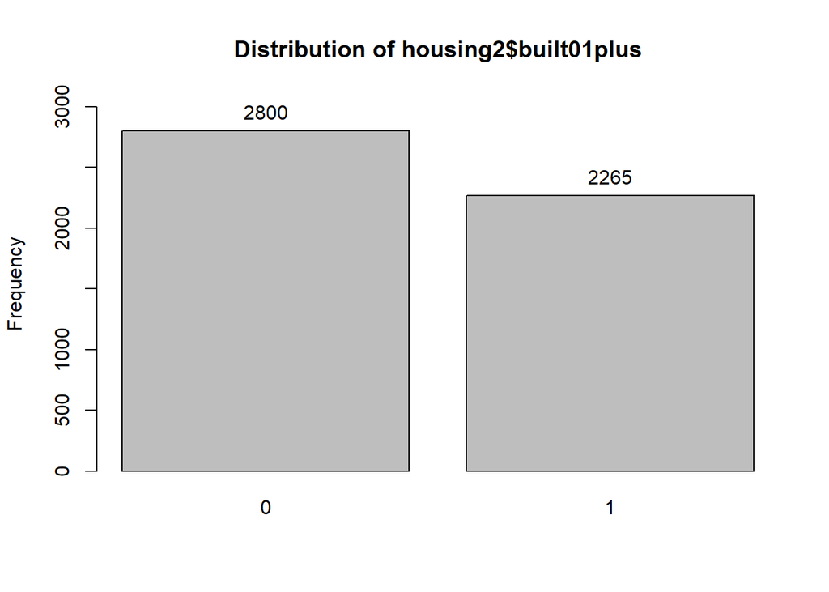

```
## housing2$built01plus :
##         Frequency Percent Cum. percent
## 0            2800    55.3         55.3
## 1            2265    44.7        100.0
##   Total      5065   100.0        100.0
```

```r
#table(housing2$built01plus)
library(epiDisplay)
# he tab1() function also prints a bar chart to show relative frequencies by default.
tab1(housing2$built01plus, sort.group = "decreasing", cum.percent = TRUE)
```

and now we run the regression.

```r
reg<-lm(price~built01plus, data = housing2)
# summary(reg)
# anova(reg)
library(stargazer)
stargazer(reg, type="text")
```

```
##
## ===============================================
##                         Dependent variable:
##                     ---------------------------
##                                price
## -----------------------------------------------
## built01plus                -17,498.200*
##                             (9,239.704)
##
## Constant                  304,126.600***
##                             (6,178.776)
##
## -----------------------------------------------
## Observations                   5,065
## R2                             0.001
## Adjusted R2                    0.001
## Residual Std. Error   326,950.100 (df = 5063)
## F Statistic            3.586* (df = 1; 5063)
## ===============================================
## Note:               *p<0.1; **p<0.05; ***p<0.01
```

The estimate associated with $\beta_1$ is the average price of a house built before 2001 while the estimate for $\beta_2$ gives the difference between the average prices for the two periods.

We can easily confirm this:

```r
library(dplyr)
housing2  %>%  group_by(built01plus) %>% summarise_at(vars(price), funs(mean))
```

```
## # A tibble: 2 x 2
##   built01plus   price
##         <dbl>   <dbl>
## 1           0 304127.
## 2           1 286628.
```

What if I wanted to define the dummy the other way around, taking the value 1 for the period before 2001 and 0 elsewhere?

```r
housing2$before2000 <- ifelse(housing2$built01plus == 0, 1, 0)

reg<-lm(price~before2000, data = housing2)
# summary(reg)
# anova(reg)
library(stargazer)
stargazer(reg, type="text")
```

```
##
## ===============================================
##                         Dependent variable:
##                     ---------------------------
##                                price
## -----------------------------------------------
## before2000                  17,498.200*
##                             (9,239.704)
##
## Constant                  286,628.400***
##                             (6,869.852)
##
## -----------------------------------------------
## Observations                   5,065
## R2                             0.001
## Adjusted R2                    0.001
## Residual Std. Error   326,950.100 (df = 5063)
## F Statistic            3.586* (df = 1; 5063)
## ===============================================
## Note:               *p<0.1; **p<0.05; ***p<0.01
```

If we use a character vector as an argument in `lm`, R will treat the vector as a set of dummy variables. The number of dummies will be the number of characteristics (unique observations) minus 1.Take the variable *bedrooms*. Suppose that we want to run a regression that includes a dummy variable for each number of bedrooms.

First, check levels in the variable *bedrooms*.

```r
housing2  %>%  group_by(bedrooms) %>% summarise_at(vars(price), funs(mean))
```

```
## # A tibble: 6 x 2
##   bedrooms    price
##      <dbl>    <dbl>
## 1        1  228556.
## 2        2  262320.
## 3        3  225694.
## 4        4  353477.
## 5        5  613780.
## 6        6 1327693.
```

Then we run regressions on the newly created factor variable *bedrooms2*.

```r
housing2$bedrooms2 <- factor(housing2$bedrooms,
                       levels = c(1,2,3,4,5,6),
                       labels = c("one bedroom", "two bedrooms", "three bedrooms", "four bedrooms", "five bedrooms", "six bedrooms"))

reg<-lm(price~bedrooms2, data = housing2)
# summary(reg)
# anova(reg)
library(stargazer)
stargazer(reg, type="text", digits=4)
```

```
##
## ===================================================
##                             Dependent variable:
##                         ---------------------------
##                                    price
## ---------------------------------------------------
## bedrooms2two bedrooms           33,764.2700
##                               (103,020.3000)
##
## bedrooms2three bedrooms         -2,861.1380
##                               (100,501.1000)
##
## bedrooms2four bedrooms         124,921.5000
##                               (100,649.7000)
##
## bedrooms2five bedrooms        385,224.4000***
##                               (101,719.1000)
##
## bedrooms2six bedrooms        1,099,137.0000***
##                               (115,357.7000)
##
## Constant                      228,555.6000**
##                               (100,351.7000)
##
## ---------------------------------------------------
## Observations                       5,065
## R2                                0.1534
## Adjusted R2                       0.1526
## Residual Std. Error      301,055.1000 (df = 5059)
## F Statistic             183.3337*** (df = 5; 5059)
## ===================================================
## Note:                   *p<0.1; **p<0.05; ***p<0.01
```

We can set a specific reference category by explicitly placing one of the levels first when specifying the level. Say now we want to use “three bedrooms” as our reference category.

```r
housing2$bedrooms3 <- factor(housing2$bedrooms,
                       levels = c(3,1,2,4,5,6),
                       labels = c("three bedrooms", "one bedroom", "two bedrooms", "four bedrooms", "five bedrooms", "six bedrooms"))

reg<-lm(price~bedrooms3, data = housing2)
# summary(reg)
# anova(reg)
library(stargazer)
stargazer(reg, type="text", digits=4)
```

```
##
## ==================================================
##                            Dependent variable:
##                        ---------------------------
##                                   price
## --------------------------------------------------
## bedrooms3one bedroom           2,861.1380
##                              (100,501.1000)
##
## bedrooms3two bedrooms          36,625.4100
##                               (23,931.7900)
##
## bedrooms3four bedrooms       127,782.7000***
##                               (9,482.3480)
##
## bedrooms3five bedrooms       388,085.5000***
##                               (17,502.4300)
##
## bedrooms3six bedrooms       1,101,998.0000***
##                               (57,157.2000)
##
## Constant                     225,694.4000***
##                               (5,478.2580)
##
## --------------------------------------------------
## Observations                      5,065
## R2                               0.1534
## Adjusted R2                      0.1526
## Residual Std. Error     301,055.1000 (df = 5059)
## F Statistic            183.3337*** (df = 5; 5059)
## ==================================================
## Note:                  *p<0.1; **p<0.05; ***p<0.01
```

Another possibility is to not use a base category, but now we better drop the constant or we will have a perfect multicollinearity problem.

```r
reg<-lm(price~bedrooms2+0, data = housing2)
summary(reg)
```

```
##
## Call:
## lm(formula = price ~ bedrooms2 + 0, data = housing2)
##
## Residuals:
##      Min       1Q   Median       3Q      Max
## -1172293  -114577   -62794    14523  4636220
##
## Coefficients:
##                         Estimate Std. Error t value Pr(>|t|)
## bedrooms2one bedroom      228556     100352   2.278   0.0228 *
## bedrooms2two bedrooms     262320      23296  11.260   <2e-16 ***
## bedrooms2three bedrooms   225694       5478  41.198   <2e-16 ***
## bedrooms2four bedrooms    353477       7740  45.670   <2e-16 ***
## bedrooms2five bedrooms    613780      16623  36.924   <2e-16 ***
## bedrooms2six bedrooms    1327693      56894  23.336   <2e-16 ***
## ---
## Signif. codes:  0 '***' 0.001 '**' 0.01 '*' 0.05 '.' 0.1 ' ' 1
##
## Residual standard error: 301100 on 5059 degrees of freedom
## Multiple R-squared:  0.5351, Adjusted R-squared:  0.5346
## F-statistic: 970.5 on 6 and 5059 DF,  p-value: < 2.2e-16
```

```r
anova(reg)
```

```
## Analysis of Variance Table
##
## Response: price
##             Df     Sum Sq    Mean Sq F value    Pr(>F)
## bedrooms2    6 5.2776e+14 8.7960e+13   970.5 < 2.2e-16 ***
## Residuals 5059 4.5852e+14 9.0634e+10
## ---
## Signif. codes:  0 '***' 0.001 '**' 0.01 '*' 0.05 '.' 0.1 ' ' 1
```

```r
library(stargazer)
stargazer(reg, type="text", digits=4)
```

```
##
## ===================================================
##                             Dependent variable:
##                         ---------------------------
##                                    price
## ---------------------------------------------------
## bedrooms2one bedroom          228,555.6000**
##                               (100,351.7000)
##
## bedrooms2two bedrooms         262,319.8000***
##                                (23,296.3400)
##
## bedrooms2three bedrooms       225,694.4000***
##                                (5,478.2580)
##
## bedrooms2four bedrooms        353,477.1000***
##                                (7,739.7420)
##
## bedrooms2five bedrooms        613,779.9000***
##                                (16,622.9900)
##
## bedrooms2six bedrooms        1,327,693.0000***
##                                (56,894.0600)
##
## ---------------------------------------------------
## Observations                       5,065
## R2                                0.5351
## Adjusted R2                       0.5346
## Residual Std. Error      301,055.1000 (df = 5059)
## F Statistic             970.4974*** (df = 6; 5059)
## ===================================================
## Note:                   *p<0.1; **p<0.05; ***p<0.01
```

Finally, what if we want to include a dummy only “6 bedrooms”? It is very easy to create individual dummies based on a categorical variable.

```r
housing2$bedroom6<-ifelse(housing2$bedrooms == 6, 1, 0)
#housing2$bedroom6 = as.integer(housing2$bedrooms == 6)
reg<-lm(price~bedroom6+0, data = housing2)
# summary(reg)
# anova(reg)
library(stargazer)
stargazer(reg, type="text", digits=4)
```

```
##
## ===============================================
##                         Dependent variable:
##                     ---------------------------
##                                price
## -----------------------------------------------
## bedroom6                 1,327,693.0000***
##                            (81,287.8900)
##
## -----------------------------------------------
## Observations                   5,065
## R2                            0.0500
## Adjusted R2                   0.0499
## Residual Std. Error  430,135.1000 (df = 5064)
## F Statistic         266.7739*** (df = 1; 5064)
## ===============================================
## Note:               *p<0.1; **p<0.05; ***p<0.01
```